Sphyrna_lewini

BOLDGenotyper v1.0.0

# Sphyrna_lewini

BOLDGenotyper Analysis Report

Generated: 2025-11-19 21:51:46

617

Total Samples

6

Genotypes

96.1%

Assignment Rate

## Analysis Summary

Total Samples

617

Samples analyzed

With Sequence Data

598

96.9% of total

Consensus Groups

6

Unique genotypes identified

Species Identified

1

Distinct species

Successfully Assigned

593

96.1% assignment rate

For assigned samples

Geographic coverage

## Pipeline Parameters

The following parameters were used for this analysis:

| Parameter | Value | Description |
| --- | --- | --- |
| **Clustering Threshold** | `0.03` (97.0% identity) | Maximum genetic distance for grouping sequences into consensus genotypes. Lower values create more groups with tighter genetic similarity. |
| **Similarity Threshold** | `0.5` (50% identity) | Minimum sequence identity required for assigning samples to genotypes. Samples below this threshold are marked as unassigned. |
| **Tie Margin** | `0.001` (0.1% difference) | Maximum identity difference between top matches to flag as ambiguous. Samples with (best - runner-up) < tie margin are flagged for manual review. |
| **Tie Threshold** | `0.9` (90% identity) | Minimum best-match identity required to consider tie detection. Prevents flagging low-quality matches as ties. |
| **Threads** | `4` | Number of parallel processing threads used. |
| **Phylogenetic Tree** | `True` | Whether phylogenetic tree was constructed. |

## Genotype Assignment Results

### Assignment Status Breakdown

| Status | Count | Percentage |
| --- | --- | --- |
| Successfully Assigned | 593 | 96.1% |
| Low Confidence | 0 | 0.0% |
| Tied Assignment | 2 | 0.3% |
| Below Threshold | 3 | 0.5% |
| No Sequence Data | 19 | 3.1% |

### Identity Score Statistics (Assigned Samples)

[output not shown]

## Taxonomy

### Consensus Group Taxonomy

| consensus_group | assigned_sp | assignment_level | assignment_notes | majority_fraction |
| --- | --- | --- | --- | --- |
| consensus_c1_n217 | Sphyrna lewini | species | majority 1.00 | 1.0 |
| consensus_c2_n249 | Sphyrna lewini | species | majority 1.00 | 1.0 |
| consensus_c3_n5 | Sphyrna lewini | species | majority 1.00 | 1.0 |
| consensus_c4_n122 | Sphyrna lewini | species | majority 1.00 | 1.0 |
| consensus_c5_n1 | Sphyrna lewini | species | majority 1.00 | 1.0 |
| consensus_c6_n1 | Sphyrna lewini | species | majority 1.00 | 1.0 |

### Species Composition by Consensus Group

| consensus_group | reported_species | n | frac | n_in_group |
| --- | --- | --- | --- | --- |
| consensus_c1_n217 | Sphyrna lewini | 217 | 1.0 | 217.0 |
| consensus_c2_n249 | Sphyrna lewini | 249 | 1.0 | 249.0 |
| consensus_c3_n5 | Sphyrna lewini | 5 | 1.0 | 5.0 |
| consensus_c4_n122 | Sphyrna lewini | 122 | 1.0 | 122.0 |
| consensus_c5_n1 | Sphyrna lewini | 1 | 1.0 | 1.0 |
| consensus_c6_n1 | Sphyrna lewini | 1 | 1.0 | 1.0 |
| NaN | Sphyrna lewini | 22 | NaN | NaN |

## Geographic Distribution

**Geographic Analysis Summary:** 71 of 617 samples (11.5%) have defined geographic locations. 546 samples (88.5%) with unknown or missing geography were excluded from geographic analyses.

### Sample Distribution by Ocean Basin

| Ocean Basin | Sample Count | Percentage |
| --- | --- | --- |
| South China and Easter Archipelagic Seas | 39 | 54.9 |
| Indian Ocean | 21 | 29.6 |
| South Atlantic Ocean | 4 | 5.6 |
| North Atlantic Ocean | 3 | 4.2 |
| South Pacific Ocean | 3 | 4.2 |
| North Pacific Ocean | 1 | 1.4 |

### Genotypes per Ocean Basin

| ocean_basin | consensus_group | Indian Ocean | North Atlantic Ocean | North Pacific Ocean | South Atlantic Ocean | South China and Easter Archipelagic Seas | South Pacific Ocean |
| --- | --- | --- | --- | --- | --- | --- | --- |
|  | consensus_c1_n217 | 18 | 0 | 0 | 3 | 2 | 0 |
|  | consensus_c2_n249 | 2 | 0 | 0 | 1 | 29 | 1 |
|  | consensus_c3_n5 | 0 | 2 | 0 | 0 | 0 | 0 |
|  | consensus_c4_n122 | 1 | 0 | 1 | 0 | 8 | 2 |
|  | consensus_c6_n1 | 0 | 1 | 0 | 0 | 0 | 0 |

## Visualizations

### Identity Distribution

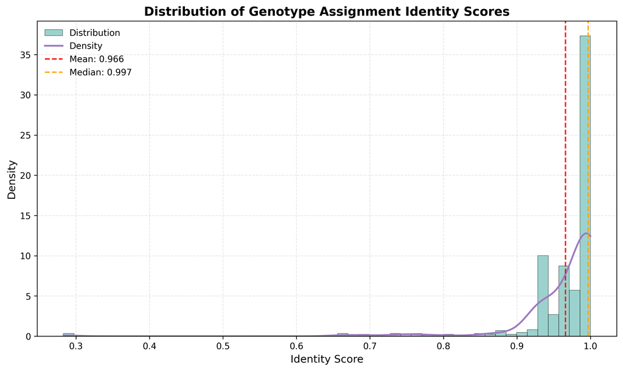

### Phylogenetic Tree

Phylogenetic tree showing relationships between consensus groups

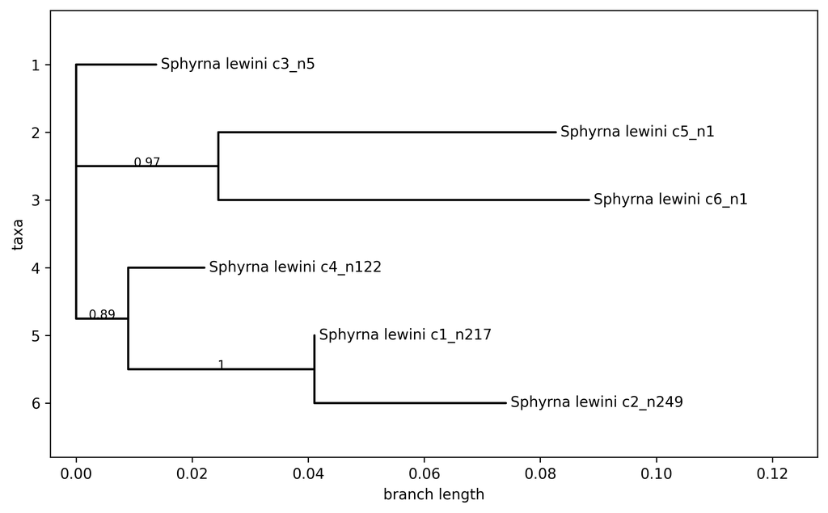

### Relative Abundance by Ocean Basin

Relative abundance of genotypes across ocean basins

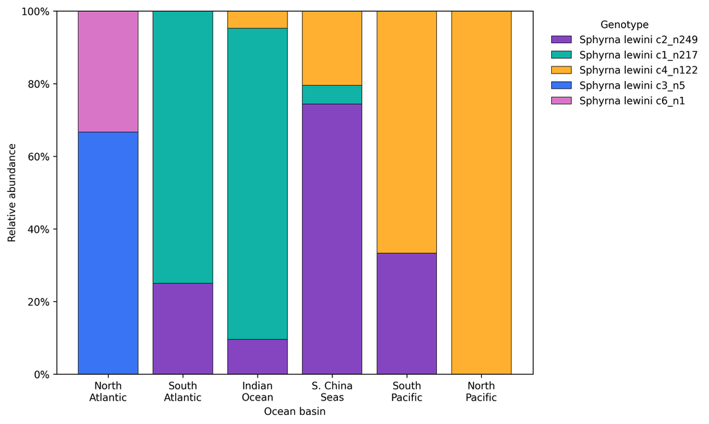

### Total Abundance by Ocean Basin

Total sample counts of genotypes across ocean basins

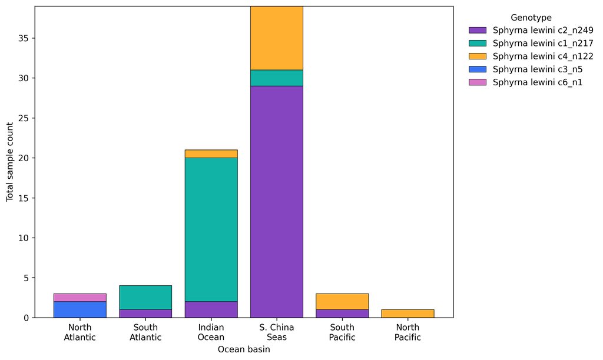

### Total Abundance by Ocean Basin (Faceted)

Total sample counts faceted by species or genotype

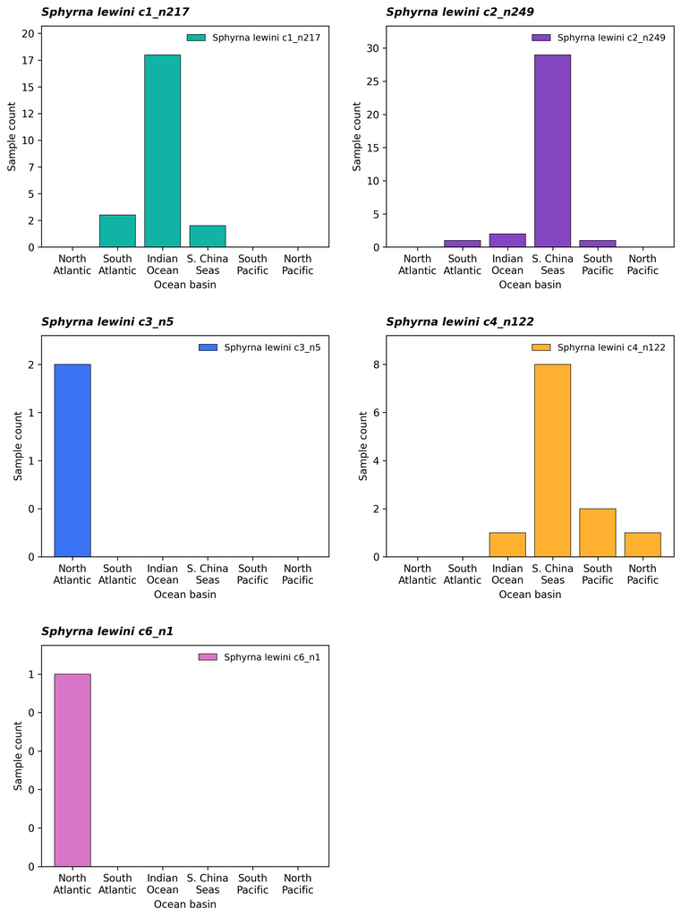

### Distribution Map

Geographic distribution of samples

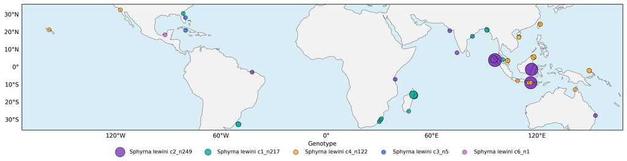

### Distribution Map (Faceted)

Geographic distribution faceted by species or genotype

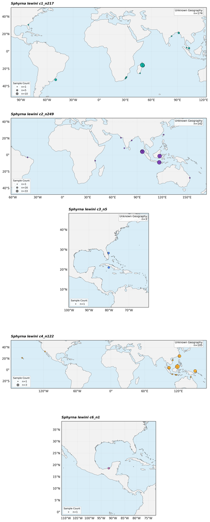

**BOLDGenotyper** - Automated genotyping pipeline for BOLD barcode data  
[GitHub Repository](https://github.com/anthropics/boldgenotyper)

Report generated on 2025-11-19 21:51:46  
For questions or issues, please visit the GitHub repository.